# Clustering Kemiskinan

### Pengujian asumsi kecukupan data dan uji kelayakan model (KMO)

Uji kecukupan data menggunakan metode Kaiser-Mayer-Olkin (KMO) dan uji kelayakan setiap variabel menggunakan Measure of Sampling Adequacy (MSA).

```r
kmo_res <- psych::KMO(cor_matrix)
kmo_res
```

```
## Kaiser-Meyer-Olkin factor adequacy
## Call: psych::KMO(r = cor_matrix)
## Overall MSA =  0.57
## MSA for each item =
##   X1   X2   X4   X6   X7   X8
## 0.48 0.53 0.83 0.62 0.59 0.44
```

Variabel X8 tetap dipertahankan karena tujuan PCA adalah reduksi dimensi sebelum clustering, bukan mencari faktor.

### Uji korelasi antar variabel (multikolinearitas)

```r
# 2.3 Bartlett's test of sphericity
bart_res <- psych::cortest.bartlett(cor_matrix, n = nrow(data_seleksi))
bart_res  # lihat chi-square dan p-value
```

```
## $chisq
## [1] 66.99936
##
## $p.value
## [1] 1.520684e-08
##
## $df
## [1] 15
```

### Menentukan banyak faktor yang terbentuk dari nilai eigen

```r
# Matriks korelasi
R <- cor(data_seleksi)

# Hitung eigenvalue dan eigenvector
eig <- eigen(R)

# Tampilkan eigenvalue
eig$values
```

```
## [1] 3.0443745 1.2178429 0.7549878 0.4690787 0.4109244 0.1027917
```

Ambil yang eigenvalue > 1 untuk menentukan banyak komponen PCA-nya. Dari hasil diperoleh ada 2 nilai yang akan diambil menjadi komponen utama (PC1 dan PC2).

### Proses pembentukan komponen utama

```r
rownames(data_seleksi) <- pempro$`Kabupaten/Kota`
pcadata <- princomp(data_seleksi, cor = TRUE, score = TRUE)
summary(pcadata)
```

```
## Importance of components:
##                           Comp.1    Comp.2    Comp.3     Comp.4     Comp.5
## Standard deviation     1.7448136 1.1035592 0.8689003 0.68489320 0.64103389
## Proportion of Variance 0.5073958 0.2029738 0.1258313 0.07817978 0.06848741
## Cumulative Proportion  0.5073958 0.7103696 0.8362009 0.91438065 0.98286806
##                            Comp.6
## Standard deviation     0.32061137
## Proportion of Variance 0.01713194
## Cumulative Proportion  1.00000000
```

Proportion of variance menjelaskan seberapa banyak komponen berkontribusi dalam menjelaskan data.

##### Menampilkan vektor eigen yang akan digunakan untuk menentukan kombinasi linear dari setiap komponen utama

```r
loadings(pcadata)
```

```
##
## Loadings:
##    Comp.1 Comp.2 Comp.3 Comp.4 Comp.5 Comp.6
## X1  0.422  0.190  0.714                0.522
## X2 -0.497 -0.354 -0.132 -0.174 -0.177  0.741
## X4 -0.434  0.238  0.249  0.688 -0.461
## X6  0.381 -0.512        -0.129 -0.731 -0.176
## X7  0.412 -0.319 -0.399  0.680  0.201  0.260
## X8 -0.268 -0.647  0.492  0.127  0.422 -0.271
##
##                Comp.1 Comp.2 Comp.3 Comp.4 Comp.5 Comp.6
## SS loadings     1.000  1.000  1.000  1.000  1.000  1.000
## Proportion Var  0.167  0.167  0.167  0.167  0.167  0.167
## Cumulative Var  0.167  0.333  0.500  0.667  0.833  1.000
```

Nilai loadings menunjukkan seberapa kuat suatu variabel mempengaruhi komponen utama, nilai kosong itu soalnya nilainya mendekati 0 jadi ga kebaca.

##### Ambil dua komponen yaitu PC1 dan PC2 karena eigenvalues-nya > 1

```r
pca_scores <- pcadata$scores[, 1:2]
pca_scores
```

```
##                      Comp.1     Comp.2
## Bogor             0.1922127  1.3498164
## Sukabumi         -0.6716553  0.5781075
## Cianjur          -1.3256040 -1.0903925
## Bandung           0.5266239  1.0680782
## Garut            -3.0053462  1.2666470
## Tasikmalaya      -2.8135593  1.5142358
## Ciamis           -0.2604521 -0.9253795
## Kuningan         -0.1723528 -1.8239882
## Cirebon           0.1933259 -0.9566623
## Majalengka       -0.8310039 -1.5906914
## Sumedang         -1.1229718 -1.5599048
## Indramayu        -1.2173585 -2.0347399
## Subang            0.5512961 -1.6783549
## Purwakarta        0.7278636 -0.6473785
## Karawang          0.8879354 -0.2554085
## Bekasi            0.9547966  1.4210776
## Bandung Barat    -0.4058433  0.8767195
## Pangandaran      -4.5149757  0.1382224
## Kota Bogor        2.0497416  0.4813691
## Kota Sukabumi     1.2042198  0.2274041
## Kota Bandung      1.5039048  1.0515611
## Kota Cirebon      1.7127463  0.2455766
## Kota Bekasi       3.0027182 -0.1298835
## Kota Depok        3.0283735  0.5210309
## Kota Cimahi       2.0591250 -0.1614673
## Kota Tasikmalaya -1.4883835  1.3642560
## Kota Banjar      -0.7653774  0.7501493
```

## K-Means dari Data PCA

### Menghitung jarak antar observasi (berdasarkan skor PCA)

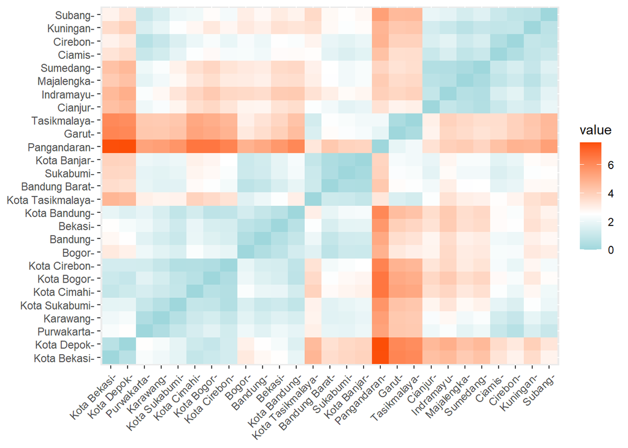

```r
library(factoextra)
jarak <- get_dist(pca_scores)
fviz_dist(jarak, gradient = list(low = "#00AFBB", mid = "white", high = "#FC4E07"))
```

Menentukan banyaknya cluster optimal (Silhouette, di ruang PCA)

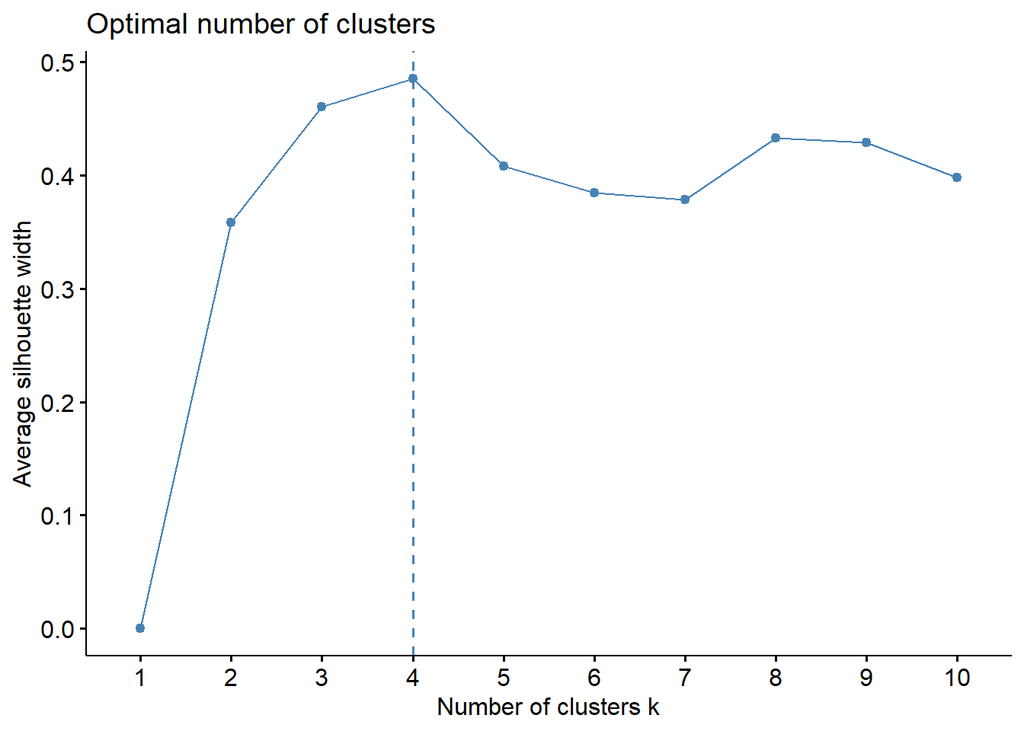

```r
fviz_nbclust(pca_scores, kmeans, method = "silhouette")
```

### Pembentukan Cluster (misal k = 4, dari silhouette)

```r
set.seed(123)
kmeans4 <- kmeans(pca_scores, centers = 4, nstart = 25)
kmeans4
```

```
## K-means clustering with 4 clusters of sizes 7, 8, 9, 3
##
## Cluster means:
##       Comp.1     Comp.2
## 1 -0.2368037  1.0583149
## 2  1.9310956  0.2475228
## 3 -0.3841397 -1.3674991
## 4 -3.4446271  0.9730350
##
## Clustering vector:
##            Bogor         Sukabumi          Cianjur          Bandung
##                1                1                3                1
##            Garut      Tasikmalaya           Ciamis         Kuningan
##                4                4                3                3
##          Cirebon       Majalengka         Sumedang        Indramayu
##                3                3                3                3
##           Subang       Purwakarta         Karawang           Bekasi
##                3                3                2                1
##    Bandung Barat      Pangandaran       Kota Bogor    Kota Sukabumi
##                1                4                2                2
##     Kota Bandung     Kota Cirebon      Kota Bekasi       Kota Depok
##                2                2                2                2
##      Kota Cimahi Kota Tasikmalaya      Kota Banjar
##                2                1                1
##
## Within cluster sum of squares by cluster:
## [1] 4.919108 5.568587 6.628056 2.812879
##  (between_SS / total_SS =  82.7 %)
##
## Available components:
##
## [1] "cluster"      "centers"      "totss"        "withinss"     "tot.withinss"
## [6] "betweenss"    "size"         "iter"         "ifault"
```

### Visualisasi cluster (di ruang PCA)

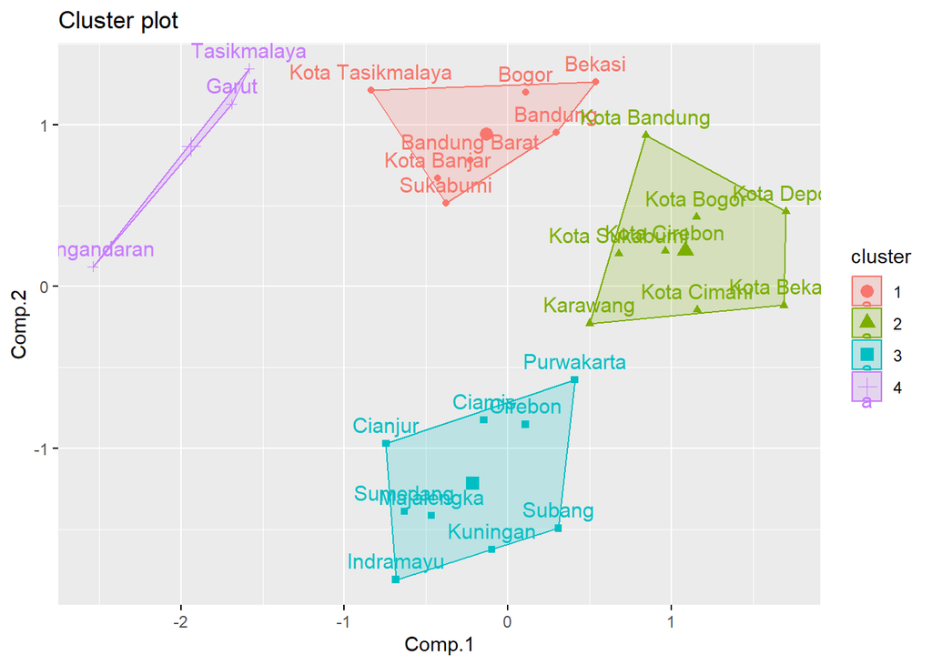

```r
fviz_cluster(kmeans4, data = pca_scores)
```

### Silhouette score keseluruhan

```r
library(ggpubr)
library(cluster)
sil_kmeans <- silhouette(kmeans4$cluster, dist(pca_scores))
mean_sil <- mean(sil_kmeans[, 3])
cat("Rata-rata silhouette K-Means (k = 4):", round(mean_sil, 3), "\n")
```

```
## Rata-rata silhouette K-Means (k = 4): 0.485
```

```
##   cluster size ave.sil.width
## 1       1    7          0.42
## 2       2    8          0.49
## 3       3    9          0.50
## 4       4    3          0.56
```

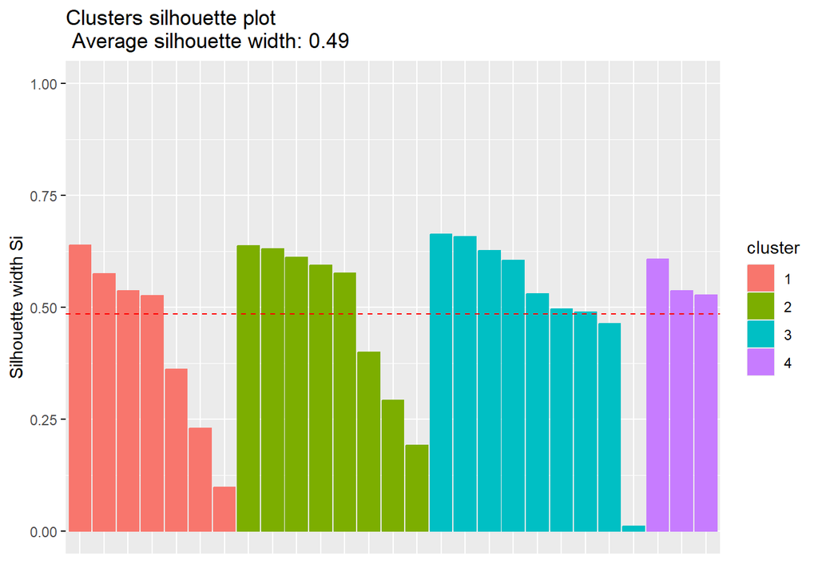

```r
fviz_silhouette(sil_kmeans)
```

### Data frame hasil pengelompokkan

```r
hasil_km <- data.frame(pempro, cluster_km = kmeans4$cluster)
hasil_km
```

```
##                    Kabupaten.Kota    X1    X2    X3    X4    X5     X6     X7
## Bogor                       Bogor 42.12 24.35 33.53 62.81 37.19  79.77  92.83
## Sukabumi                 Sukabumi 40.40 37.22 22.38 67.45 32.55  94.16  89.38
## Cianjur                   Cianjur 37.36 42.34 20.30 66.02 33.98  92.71  93.89
## Bandung                   Bandung 38.87 26.07 35.06 64.58 35.42  91.80  94.30
## Garut                       Garut 38.26 39.13 22.60 68.37 31.63  78.97  78.24
## Tasikmalaya           Tasikmalaya 36.83 41.48 21.68 67.93 32.07  79.79  80.22
## Ciamis                     Ciamis 35.60 40.75 23.65 64.75 35.25  97.07 100.00
## Kuningan                 Kuningan 41.32 35.58 23.11 63.53 36.47  97.54  95.19
## Cirebon                   Cirebon 41.39 31.31 27.30 63.35 36.65  93.48  96.34
## Majalengka             Majalengka 36.38 36.14 27.48 64.77 35.23  99.27  92.59
## Sumedang                 Sumedang 34.39 40.92 24.69 65.79 34.21  92.55 100.00
## Indramayu               Indramayu 37.76 40.76 21.47 64.30 35.70  98.14  91.36
## Subang                     Subang 39.98 35.91 24.11 58.97 41.03  96.81  97.63
## Purwakarta             Purwakarta 40.40 27.89 31.71 62.28 37.72  97.13  95.68
## Karawang                 Karawang 43.45 31.24 25.31 59.02 40.98  99.88  87.46
## Bekasi                     Bekasi 42.19 22.12 35.69 65.28 34.72  88.34  96.17
## Bandung Barat       Bandung Barat 41.40 30.48 28.12 65.86 34.14  81.97  94.45
## Pangandaran           Pangandaran 25.10 50.83 24.07 68.40 31.60  74.47  88.21
## Kota Bogor             Kota Bogor 44.58 17.24 38.18 65.59 34.41 100.00  98.57
## Kota Sukabumi       Kota Sukabumi 42.78 26.56 30.66 66.09 33.91 100.00  97.17
## Kota Bandung         Kota Bandung 41.91 24.01 34.07 60.91 39.09  90.35  96.79
## Kota Cirebon         Kota Cirebon 44.40 22.30 33.30 60.74 39.26  89.26 100.00
## Kota Bekasi           Kota Bekasi 41.56 17.83 40.61 54.15 45.85 100.00  98.09
## Kota Depok             Kota Depok 40.43 18.31 41.26 56.42 43.58 100.00 100.00
## Kota Cimahi           Kota Cimahi 39.74 21.43 38.83 60.10 39.90 100.00 100.00
## Kota Tasikmalaya Kota Tasikmalaya 39.15 26.03 34.82 71.27 28.73  79.32  91.05
## Kota Banjar           Kota Banjar 40.80 32.07 27.13 69.81 30.19  95.34  87.53
##                    X8   X9 cluster_km
## Bogor            1.08 0.26          1
## Sukabumi         0.88 0.20          1
## Cianjur          1.58 0.41          3
## Bandung          0.61 0.09          1
## Garut            1.41 0.29          4
## Tasikmalaya      1.01 0.15          4
## Ciamis           0.99 0.20          3
## Kuningan         2.02 0.53          3
## Cirebon          1.69 0.36          3
## Majalengka       1.76 0.45          3
## Sumedang         1.60 0.45          3
## Indramayu        2.05 0.54          3
## Subang           1.63 0.46          3
## Purwakarta       1.37 0.35          3
## Karawang         1.18 0.28          2
## Bekasi           0.70 0.17          1
## Bandung Barat    1.17 0.23          1
## Pangandaran      1.23 0.29          4
## Kota Bogor       0.95 0.24          2
## Kota Sukabumi    0.88 0.18          2
## Kota Bandung     0.60 0.14          2
## Kota Cirebon     1.18 0.25          2
## Kota Bekasi      0.80 0.21          2
## Kota Depok       0.34 0.07          2
## Kota Cimahi      0.83 0.21          2
## Kota Tasikmalaya 1.35 0.26          1
## Kota Banjar      1.03 0.29          1
```

### Save K-Means

```r
library(writexl)
#write_xlsx(mean_total,"D:\\IPB\\Pemrograman Statistka\\Rata-Rata Cluster.xlsx")
#write_xlsx(hasil_km,"D:\\IPB\\Pemrograman Statistka\\Clustering K-Means Fix.xlsx")
```

## Visualisasi

### Peta Klasterisasi

```r
library(sf)
```

```r
library(dplyr)
library(ggplot2)
```

```r
#indo_kab <- st_read("D:/Pascasarjana IPB/Semester 1/Pemograman Statistika/Pempro Project/Admin2Kabupaten/idn_admbnda_adm2_bps_20200401.shp")
```

```r
# Filter Jabar + hapus waduk
#jabar_map <- indo_kab %>%
  #filter(ADM1_EN == "Jawa Barat") %>%
  #filter(!ADM2_EN %in% c("Waduk Cirata", "Cirata Reservoir", "Waduk Jatiluhur"))

# Join dengan data cluster
#jabar_cluster <- jabar_map %>%
  #left_join(hasil, by = c("ADM2_EN" = "Kabupaten_Kota"))

# Plot peta
#ggplot(jabar_cluster) +
  #geom_sf(aes(fill = factor(Cluster))) +
  #geom_sf_text(aes(label = ADM2_EN), size = 3, color = "black") +
  #scale_fill_brewer(palette = "Set2") +
  #labs(title = "Peta Cluster Kemiskinan Jawa Barat",
       #fill = "Cluster") +
  #theme_minimal()
```

### Radar Chart

```r
library(dplyr)
library(fmsb)
library(scales)
# --- Rata-rata tiap variabel X per cluster K-means ---
mean_table_km <- hasil_km %>%
  group_by(cluster_km) %>%
  summarise(across(starts_with("X"), mean, na.rm = TRUE))
mean_table_km
```

```
## # A tibble: 4 × 10
##   cluster_km    X1    X2    X3    X4    X5    X6    X7    X8    X9
##        <int> <dbl> <dbl> <dbl> <dbl> <dbl> <dbl> <dbl> <dbl> <dbl>
## 1          1  40.7  28.3  31.0  66.7  33.3  87.2  92.2 0.974 0.214
## 2          2  42.4  22.4  35.3  60.4  39.6  97.4  97.3 0.845 0.198
## 3          3  38.3  36.8  24.9  63.8  36.2  96.1  95.9 1.63  0.417
## 4          4  33.4  43.8  22.8  68.2  31.8  77.7  82.2 1.22  0.243
```

```r
# Buang kolom cluster, jadikan row = cluster
radar_df_km <- as.data.frame(mean_table_km[, -1])
rownames(radar_df_km) <- paste0("Cluster ", mean_table_km$cluster_km)

# Baris max & min (wajib untuk fmsb)
maxs_km <- apply(radar_df_km, 2, max)
mins_km <- apply(radar_df_km, 2, min)

radar_data_km <- rbind(maxs_km, mins_km, radar_df_km)
radar_data_km
```

```
##                 X1       X2       X3       X4       X5       X6       X7
## 1         42.35625 43.81333 35.27750 68.23333 39.62250 97.43625 97.26000
## 2         33.39667 22.36500 22.78333 60.37750 31.76667 77.74333 82.22333
## Cluster 1 40.70429 28.33429 30.96143 66.72286 33.27714 87.24286 92.24429
## Cluster 2 42.35625 22.36500 35.27750 60.37750 39.62250 97.43625 97.26000
## Cluster 3 38.28667 36.84444 24.86889 63.75111 36.24889 96.07778 95.85333
## Cluster 4 33.39667 43.81333 22.78333 68.23333 31.76667 77.74333 82.22333
##                  X8        X9
## 1         1.6322222 0.4166667
## 2         0.8450000 0.1975000
## Cluster 1 0.9742857 0.2142857
## Cluster 2 0.8450000 0.1975000
## Cluster 3 1.6322222 0.4166667
## Cluster 4 1.2166667 0.2433333
```

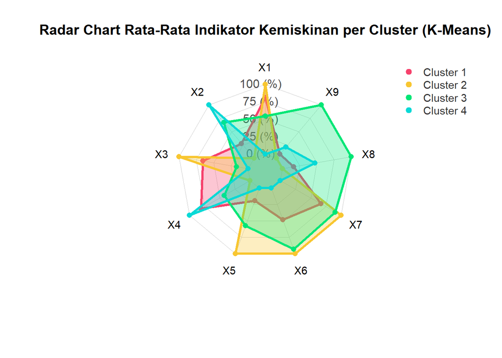

```r
# Palet warna ceria
colors_border <- c(
  "#F6416C",  # bubblegum pink
  "#F8C630",  # gold cerah
  "#00E676",  # turquoise cerah
  "#08D9D6"   # neon aqua
)

colors_in <- alpha(colors_border, 0.3)

radarchart(
  radar_data_km,
  axistype   = 1,
  pcol       = colors_border,
  pfcol      = colors_in,
  plwd       = 3,
  plty       = 1,
  cglcol     = "grey80",
  cglty      = 1,
  cglwd      = 0.8,
  axislabcol = "grey30",
  vlcex      = 0.9,
  title      = "Radar Chart Rata-Rata Indikator Kemiskinan per Cluster (K-Means)"
)

legend(
  "topright",
  legend   = rownames(radar_data_km)[-c(1, 2)],
  bty      = "n",
  pch      = 20,
  col      = colors_border,
  text.col = "grey20",
  cex      = 0.9,
  pt.cex   = 1.6
)
```

### Barplot Cluster

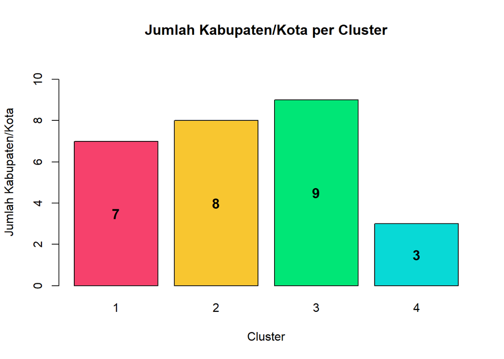

```r
# Buat tabel frekuensi
cluster_count <- table(hasil_km$cluster_km)

# Simpan posisi batang ke variabel bp
bp <- barplot(cluster_count,
              main = "Jumlah Kabupaten/Kota per Cluster",
              xlab = "Cluster",
              ylab = "Jumlah Kabupaten/Kota",
              col  = c("#F6416C", "#F8C630",
                       "#00E676","#08D9D6"),
              ylim = c(0, max(cluster_count) + 2))

# Tambahkan label di dalam batang
text(x = bp,
     y = cluster_count/2,
     labels = cluster_count,
     cex = 1.2,
     font = 2,
     col = "black")
```

### Boxplot

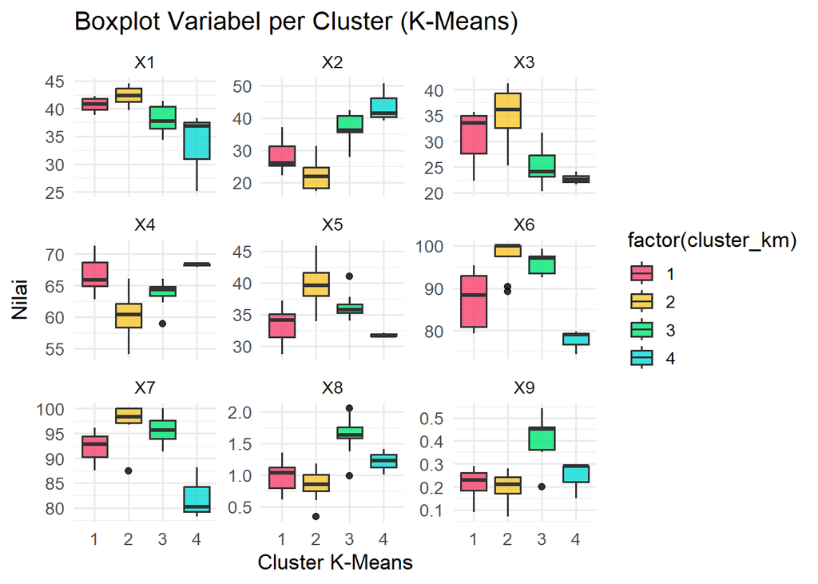

```r
data_long_km <- hasil_km %>%
  pivot_longer(
    cols      = starts_with("X"),
    names_to  = "variabel",
    values_to = "value"
  )

ggplot(data_long_km, aes(x = factor(cluster_km), y = value, fill = factor(cluster_km))) +
  geom_boxplot(alpha = 0.8, outlier.color = "black") +
  facet_wrap(~ variabel, scales = "free_y") +
  scale_fill_manual(values = c(
    "1" = "#F6416C",
    "2" = "#F8C630",
    "3" = "#00E676",
    "4" = "#08D9D6"
  )) +
  theme_minimal(base_size = 13) +
  labs(
    title = "Boxplot Variabel per Cluster (K-Means)",
    x     = "Cluster K-Means",
    y     = "Nilai"
  )
```